[figure not shown]

[OHI-Northeast](http://www.ohi-northeast.org/) | [OHI Science](http://ohi-science.org) | [Citation policy](http://ohi-science.org/citation-policy/)

# OHIEC: Resilience -Social

Compiled on Fri Sep 27 13:25:25 2019 by verstaen

# Summary

This script calculates social resilience values by OHINE region.

**3. NOAA Social Vulnerability** **Downloaded**: August 2019

**Description**: Calculates Social Vulnerability based on social vulnerability, fishing vulnerability, inundation risk, and gentrification vulnerability. https://www.st.nmfs.noaa.gov/humandimensions/social-indicators/map

The raw data was emailed to us by Lisa Colburn (lisa.l.colburn@noaa.gov)

**Time range**: 2009-2016

**Format**: Tabular

# About

Each community is scored in 4 indicators: Social Vulnerability, Gentrification Pressure, Sea Level Rise Vulnerability, Fishing Engagement and Reliance. The factors used to calculate individual scores are:

LabFrc_ct Labor Force categorical ranking HsChr_ct Housing Characteristics categorical ranking Pvrty_ct Poverty categorical ranking PopCom_ct Population Composition categorical ranking PerDis_ct Personal Disruption categorical ranking HsDis_ct Housing Disruption categorical ranking RetMig_ct Retiree Migration categorical ranking UrbSpl_ct Urban Sprawl categorical ranking ComEng_ct Commercial Fishing Engagement categorical ranking ComRel_ct Commercial Reliance categorical ranking RecEng_ct Recreational Engagement categorical ranking RecRel_ct Recreational Reliance categorical ranking SLR_ct Inundation Risk categorical ranking SS_ct Storm Surge Risk categorical Ranking (2015 and 2016 only)

Total overall vulnerability index score was then calculated by taking the average of all 4 indicator scores.

# Methods

## Set up, libraries, load data

```r
knitr::opts_chunk$set(fig.width = 6, fig.height = 4, fig.path = 'figs/',
                      message = FALSE, warning = FALSE)

source('~/github/ne-prep/src/R/common.R')  ### an OHINE specific version of common.R
dir_git <- '~/github/ne-prep'
dir_anx <- file.path(dir_M, 'git-annex/neprep')

library(csv)
library(dplyr)
library(tidyverse)
library(readxl)
library(gridExtra)
library(scales)
```

NOAA Social Vulnerability Index

```r
raw_svi_2009 <- read_excel(file.path(dir_anx, "_raw_data/NOAA_Social/2009-2016_National_Indicators_updated_082119_Juliette Verstaen.xlsx"), sheet=1)
raw_svi_2010 <- read_excel(file.path(dir_anx, "_raw_data/NOAA_Social/2009-2016_National_Indicators_updated_082119_Juliette Verstaen.xlsx"), sheet=2)
raw_svi_2011 <- read_excel(file.path(dir_anx, "_raw_data/NOAA_Social/2009-2016_National_Indicators_updated_082119_Juliette Verstaen.xlsx"), sheet=3)
raw_svi_2012 <- read_excel(file.path(dir_anx, "_raw_data/NOAA_Social/2009-2016_National_Indicators_updated_082119_Juliette Verstaen.xlsx"), sheet=4)
raw_svi_2013 <- read_excel(file.path(dir_anx, "_raw_data/NOAA_Social/2009-2016_National_Indicators_updated_082119_Juliette Verstaen.xlsx"), sheet=5)
raw_svi_2014 <- read_excel(file.path(dir_anx, "_raw_data/NOAA_Social/2009-2016_National_Indicators_updated_082119_Juliette Verstaen.xlsx"), sheet=6)
raw_svi_2015 <- read_excel(file.path(dir_anx, "_raw_data/NOAA_Social/2009-2016_National_Indicators_updated_082119_Juliette Verstaen.xlsx"), sheet=7)
raw_svi_2016 <- read_excel(file.path(dir_anx, "_raw_data/NOAA_Social/2009-2016_National_Indicators_updated_082119_Juliette Verstaen.xlsx"), sheet=8)
raw_svi_categories <- read_excel(file.path(dir_anx, "_raw_data/NOAA_Social/2009-2016_National_Indicators_updated_082119_Juliette Verstaen.xlsx"), sheet=11)

MA_counties <- read.csv("~/github/ne-prep/src/tables/MA_counties.csv") %>%
  select(-X)
MA_cities <- read_csv(file.path(dir_anx, "_raw_data/MA_gov/list-cities-massachusetts.csv")) %>% select(Name, County) %>%
  rename(city = Name)
```

## Tidying

First we need to divide the regions of Massachusetts North and South. The vulnerability index looked at communities not counties, but most of them do match up to counties. For the rest I manually went and and looked where they were and assigned the community to a region

Look at Massachusetts “counties” in the SVI and see if they match up with the actual counties

```r
ma_communities <- raw_svi_2009 %>%
  select(GEO_NAME) %>%
  separate(GEO_NAME, c("city", "state"), sep= ", ") %>%
  filter(state == "MA") %>%
  left_join(MA_cities, by = c("city")) %>%
  rename(city_community = city)

#pull out the communities with NA for county
county_missing <- ma_communities %>%
  filter(is.na(County))

write.csv(county_missing, file = "data/county_missing.csv")

#between this line and above I manually went in and assigned North/South to the NA communitites.
#this file is the above file with the counties filled in
MA_counties_missing <- read.csv(file.path(dir_anx, "_raw_data/MA_gov/county_missing_filled.csv"))
```

Look to see where the division of north and south massachusetts is on the cape

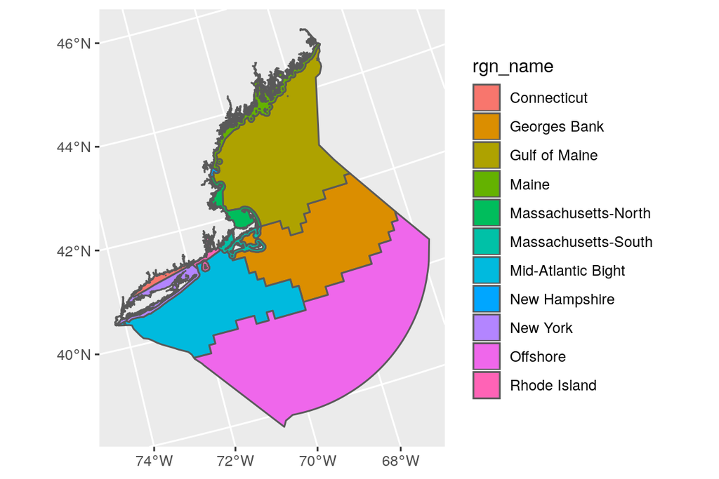

```r
regions_map <- ggplot(rgns) +
  geom_sf(aes(fill= rgn_name))
regions_map
```

Combine

```r
ma_rgns_by_counties <- ma_communities %>%
  filter(!is.na(County)) %>%
  left_join(MA_counties, by =c("County")) %>%
  rbind(MA_counties_missing)
```

Now that the communities have the proper regions associated with them, we can calculate the score of the 4 indices (Social Vulnerability, Gentrification Pressure, Sea Level Rise Vulnerability, Fishing Engagement and Reliance)

Do the same data tidying for every year (2009-2016)

```r
# tidy and find score averages
calc_09 <- raw_svi_2009 %>%
  select(year, GEO_NAME, LabFrc_ct, HsChr_ct, Pvrty_ct, PopCom_ct, PerDis_ct, HsDis_ct, RetMig_ct, UrbSpl_ct, ComEng_ct, ComRel_ct, RecEng_ct, RecRel_ct, SLR_ct) %>% #no SS_ct this year
  separate(GEO_NAME, c("city_community", "state"), sep= ", ") %>%
  rowwise() %>%
  mutate(social_vul = mean(c(PerDis_ct, PopCom_ct, Pvrty_ct, LabFrc_ct, HsChr_ct, HsDis_ct)),
         gentrification_vul = mean(c(RetMig_ct, UrbSpl_ct)), #missing Natural Amenities, will ask Lisa about this
         fishing_vul = mean(c(ComEng_ct, ComRel_ct, RecEng_ct, RecRel_ct )),
         inundation_risk = SLR_ct) %>%
  select(year, state, city_community, social_vul, gentrification_vul, fishing_vul, inundation_risk) %>%
  mutate(vulnerability_score = mean(c(social_vul, gentrification_vul, fishing_vul, inundation_risk)))

noMA_09 <- calc_09%>%
  filter( state != "MA") %>%  #add rgn_id and rgn_name to rbind with MA later
   mutate(rgn_id = case_when(
    state == "ME" ~ "6",
    state == "NH" ~ "9",
    state == "RI" ~ "11",
    state == "CT" ~ "5",
    state == "NY" ~ "10")) %>%
  mutate(rgn_name = case_when(
    rgn_id == "6" ~ "Maine",
    rgn_id == "9" ~ "New Hampshire",
    rgn_id == "11" ~ "Rhode Island",
    rgn_id == "5" ~ "Connecticut",
    rgn_id == "10" ~ "New York"))

MA_09 <- calc_09 %>%
  filter(state == "MA") %>%
  right_join(ma_rgns_by_counties) %>%
  select(-County)

svi_2009 <- rbind(MA_09,noMA_09)
```

```r
calc_10 <- raw_svi_2010 %>%
  select(year, GEO_NAME, LabFrc_ct, HsChr_ct, Pvrty_ct, PopCom_ct, PerDis_ct, HsDis_ct, RetMig_ct, UrbSpl_ct, ComEng_ct, ComRel_ct, RecEng_ct, RecRel_ct, SLR_ct) %>% #no SS_ct this year
  separate(GEO_NAME, c("city_community", "state"), sep= ", ") %>%
  rowwise() %>%
  mutate(social_vul = mean(c(PerDis_ct, PopCom_ct, Pvrty_ct, LabFrc_ct, HsChr_ct, HsDis_ct)),
         gentrification_vul = mean(c(RetMig_ct, UrbSpl_ct)), #missing Natural Amenities, will ask Lisa about this
         fishing_vul = mean(c(ComEng_ct, ComRel_ct, RecEng_ct, RecRel_ct )),
         inundation_risk = SLR_ct) %>%
  select(year, state, city_community, social_vul, gentrification_vul, fishing_vul, inundation_risk) %>%
  mutate(vulnerability_score = mean(c(social_vul, gentrification_vul, fishing_vul, inundation_risk)))

noMA_10 <- calc_10%>%
  filter( state != "MA") %>%  #add rgn_id and rgn_name to rbind with MA later
   mutate(rgn_id = case_when(
    state == "ME" ~ "6",
    state == "NH" ~ "9",
    state == "RI" ~ "11",
    state == "CT" ~ "5",
    state == "NY" ~ "10")) %>%
  mutate(rgn_name = case_when(
    rgn_id == "6" ~ "Maine",
    rgn_id == "9" ~ "New Hampshire",
    rgn_id == "11" ~ "Rhode Island",
    rgn_id == "5" ~ "Connecticut",
    rgn_id == "10" ~ "New York"))

MA_10 <- calc_10 %>%
  filter(state == "MA") %>%
  right_join(ma_rgns_by_counties) %>%
  select(-County)

svi_2010 <- rbind(MA_10,noMA_10)
```

```r
calc_11 <- raw_svi_2011 %>%
  select(year, GEO_NAME, LabFrc_ct, HsChr_ct, Pvrty_ct, PopCom_ct, PerDis_ct, HsDis_ct, RetMig_ct, UrbSpl_ct, ComEng_ct, ComRel_ct, RecEng_ct, RecRel_ct, SLR_ct) %>% #no SS_ct this year
  separate(GEO_NAME, c("city_community", "state"), sep= ", ") %>%
  rowwise() %>%
  mutate(social_vul = mean(c(PerDis_ct, PopCom_ct, Pvrty_ct, LabFrc_ct, HsChr_ct, HsDis_ct)),
         gentrification_vul = mean(c(RetMig_ct, UrbSpl_ct)), #missing Natural Amenities, will ask Lisa about this
         fishing_vul = mean(c(ComEng_ct, ComRel_ct, RecEng_ct, RecRel_ct )),
         inundation_risk = SLR_ct) %>%
  select(year, state, city_community, social_vul, gentrification_vul, fishing_vul, inundation_risk) %>%
  mutate(vulnerability_score = mean(c(social_vul, gentrification_vul, fishing_vul, inundation_risk)))

noMA_11 <- calc_11%>%
  filter( state != "MA") %>%  #add rgn_id and rgn_name to rbind with MA later
   mutate(rgn_id = case_when(
    state == "ME" ~ "6",
    state == "NH" ~ "9",
    state == "RI" ~ "11",
    state == "CT" ~ "5",
    state == "NY" ~ "10")) %>%
  mutate(rgn_name = case_when(
    rgn_id == "6" ~ "Maine",
    rgn_id == "9" ~ "New Hampshire",
    rgn_id == "11" ~ "Rhode Island",
    rgn_id == "5" ~ "Connecticut",
    rgn_id == "10" ~ "New York"))

MA_11 <- calc_11 %>%
  filter(state == "MA") %>%
  right_join(ma_rgns_by_counties) %>%
  select(-County)

svi_2011 <- rbind(MA_11,noMA_11)
```

```r
calc_12 <- raw_svi_2012 %>%
  select(year, GEO_NAME, LabFrc_ct, HsChr_ct, Pvrty_ct, PopCom_ct, PerDis_ct, HsDis_ct, RetMig_ct, UrbSpl_ct, ComEng_ct, ComRel_ct, RecEng_ct, RecRel_ct, SLR_ct) %>% #no SS_ct this year
  separate(GEO_NAME, c("city_community", "state"), sep= ", ") %>%
  rowwise() %>%
  mutate(social_vul = mean(c(PerDis_ct, PopCom_ct, Pvrty_ct, LabFrc_ct, HsChr_ct, HsDis_ct)),
         gentrification_vul = mean(c(RetMig_ct, UrbSpl_ct)), #missing Natural Amenities, will ask Lisa about this
         fishing_vul = mean(c(ComEng_ct, ComRel_ct, RecEng_ct, RecRel_ct )),
         inundation_risk = SLR_ct) %>%
  select(year, state, city_community, social_vul, gentrification_vul, fishing_vul, inundation_risk) %>%
  mutate(vulnerability_score = mean(c(social_vul, gentrification_vul, fishing_vul, inundation_risk)))

noMA_12 <- calc_12%>%
  filter( state != "MA") %>%  #add rgn_id and rgn_name to rbind with MA later
   mutate(rgn_id = case_when(
    state == "ME" ~ "6",
    state == "NH" ~ "9",
    state == "RI" ~ "11",
    state == "CT" ~ "5",
    state == "NY" ~ "10")) %>%
  mutate(rgn_name = case_when(
    rgn_id == "6" ~ "Maine",
    rgn_id == "9" ~ "New Hampshire",
    rgn_id == "11" ~ "Rhode Island",
    rgn_id == "5" ~ "Connecticut",
    rgn_id == "10" ~ "New York"))

MA_12 <- calc_12 %>%
  filter(state == "MA") %>%
  right_join(ma_rgns_by_counties) %>%
  select(-County)

svi_2012 <- rbind(MA_12,noMA_12)
```

```r
calc_13 <- raw_svi_2013 %>%
  select(year, GEO_NAME, LabFrc_ct, HsChr_ct, Pvrty_ct, PopCom_ct, PerDis_ct, HsDis_ct, RetMig_ct, UrbSpl_ct, ComEng_ct, ComRel_ct, RecEng_ct, RecRel_ct, SLR_ct) %>% #no SS_ct this year
  separate(GEO_NAME, c("city_community", "state"), sep= ", ") %>%
  rowwise() %>%
  mutate(social_vul = mean(c(PerDis_ct, PopCom_ct, Pvrty_ct, LabFrc_ct, HsChr_ct, HsDis_ct)),
         gentrification_vul = mean(c(RetMig_ct, UrbSpl_ct)), #missing Natural Amenities, will ask Lisa about this
         fishing_vul = mean(c(ComEng_ct, ComRel_ct, RecEng_ct, RecRel_ct )),
         inundation_risk = SLR_ct) %>%
  select(year, state, city_community, social_vul, gentrification_vul, fishing_vul, inundation_risk) %>%
  mutate(vulnerability_score = mean(c(social_vul, gentrification_vul, fishing_vul, inundation_risk)))

noMA_13 <- calc_13%>%
  filter( state != "MA") %>%  #add rgn_id and rgn_name to rbind with MA later
   mutate(rgn_id = case_when(
    state == "ME" ~ "6",
    state == "NH" ~ "9",
    state == "RI" ~ "11",
    state == "CT" ~ "5",
    state == "NY" ~ "10")) %>%
  mutate(rgn_name = case_when(
    rgn_id == "6" ~ "Maine",
    rgn_id == "9" ~ "New Hampshire",
    rgn_id == "11" ~ "Rhode Island",
    rgn_id == "5" ~ "Connecticut",
    rgn_id == "10" ~ "New York"))

MA_13 <- calc_13 %>%
  filter(state == "MA") %>%
  right_join(ma_rgns_by_counties) %>%
  select(-County)

svi_2013 <- rbind(MA_13,noMA_13)
```

```r
calc_14 <- raw_svi_2014 %>%
  select(year, GEO_NAME, LabFrc_ct, HsChr_ct, Pvrty_ct, PopCom_ct, PerDis_ct, HsDis_ct, RetMig_ct, UrbSpl_ct, ComEng_ct, ComRel_ct, RecEng_ct, RecRel_ct, SLR_ct) %>% #no SS_ct this year
  separate(GEO_NAME, c("city_community", "state"), sep= ", ") %>%
  rowwise() %>%
  mutate(social_vul = mean(c(PerDis_ct, PopCom_ct, Pvrty_ct, LabFrc_ct, HsChr_ct, HsDis_ct)),
         gentrification_vul = mean(c(RetMig_ct, UrbSpl_ct)), #missing Natural Amenities, will ask Lisa about this
         fishing_vul = mean(c(ComEng_ct, ComRel_ct, RecEng_ct, RecRel_ct )),
         inundation_risk = SLR_ct) %>%
  select(year, state, city_community, social_vul, gentrification_vul, fishing_vul, inundation_risk) %>%
  mutate(vulnerability_score = mean(c(social_vul, gentrification_vul, fishing_vul, inundation_risk)))

noMA_14 <- calc_14%>%
  filter( state != "MA") %>%  #add rgn_id and rgn_name to rbind with MA later
   mutate(rgn_id = case_when(
    state == "ME" ~ "6",
    state == "NH" ~ "9",
    state == "RI" ~ "11",
    state == "CT" ~ "5",
    state == "NY" ~ "10")) %>%
  mutate(rgn_name = case_when(
    rgn_id == "6" ~ "Maine",
    rgn_id == "9" ~ "New Hampshire",
    rgn_id == "11" ~ "Rhode Island",
    rgn_id == "5" ~ "Connecticut",
    rgn_id == "10" ~ "New York"))

MA_14 <- calc_14 %>%
  filter(state == "MA") %>%
  right_join(ma_rgns_by_counties) %>%
  select(-County)

svi_2014 <- rbind(MA_14, noMA_14)
```

```r
calc_15 <- raw_svi_2015 %>%
  select(year, GEO_NAME, LabFrc_ct, HsChr_ct, Pvrty_ct, PopCom_ct, PerDis_ct, HsDis_ct, RetMig_ct, UrbSpl_ct, ComEng_15ct, ComRel_15ct, RecEng_ct, RecRel_ct, SLR_ct) %>% # SS_ct even though says there is
  separate(GEO_NAME, c("city_community", "state"), sep= ", ") %>%
  rowwise() %>%
  mutate(social_vul = mean(c(PerDis_ct, PopCom_ct, Pvrty_ct, LabFrc_ct, HsChr_ct, HsDis_ct)),
         gentrification_vul = mean(c(RetMig_ct, UrbSpl_ct)), #missing Natural Amenities, will ask Lisa about this
         fishing_vul = mean(c(ComEng_15ct, ComRel_15ct, RecEng_ct, RecRel_ct )),
         inundation_risk = mean(SLR_ct)) %>%
  select(year, state, city_community, social_vul, gentrification_vul, fishing_vul, inundation_risk) %>%
  mutate(vulnerability_score = mean(c(social_vul, gentrification_vul, fishing_vul, inundation_risk)))

noMA_15 <- calc_15%>%
  filter( state != "MA") %>%  #add rgn_id and rgn_name to rbind with MA later
   mutate(rgn_id = case_when(
    state == "ME" ~ "6",
    state == "NH" ~ "9",
    state == "RI" ~ "11",
    state == "CT" ~ "5",
    state == "NY" ~ "10")) %>%
  mutate(rgn_name = case_when(
    rgn_id == "6" ~ "Maine",
    rgn_id == "9" ~ "New Hampshire",
    rgn_id == "11" ~ "Rhode Island",
    rgn_id == "5" ~ "Connecticut",
    rgn_id == "10" ~ "New York"))

MA_15 <- calc_15 %>%
  filter(state == "MA") %>%
  right_join(ma_rgns_by_counties) %>%
  select(-County)

svi_2015 <- rbind(MA_15, noMA_15)
```

```r
calc_16 <- raw_svi_2016 %>%
  select(year, GEO_NAME, LabFrc_ct, HsChr_ct, Pvrty_ct, PopCom_ct, PerDis_ct, HsDis_ct, RetMig_ct, UrbSpl_ct, ComEng_ct, ComRel_ct, RecEng_ct, RecRel_ct, SLR_ct) %>% # SS_ct even though says there is
  separate(GEO_NAME, c("city_community", "state"), sep= ", ") %>%
  rowwise() %>%
  mutate(social_vul = mean(c(PerDis_ct, PopCom_ct, Pvrty_ct, LabFrc_ct, HsChr_ct, HsDis_ct)),
         gentrification_vul = mean(c(RetMig_ct, UrbSpl_ct)), #missing Natural Amenities, will ask Lisa about this
         fishing_vul = mean(c(ComEng_ct, ComRel_ct, RecEng_ct, RecRel_ct )),
         inundation_risk = mean(SLR_ct)) %>%
  select(year, state, city_community, social_vul, gentrification_vul, fishing_vul, inundation_risk) %>%
  mutate(vulnerability_score = mean(c(social_vul, gentrification_vul, fishing_vul, inundation_risk)))

noMA_16 <- calc_16%>%
  filter( state != "MA") %>%  #add rgn_id and rgn_name to rbind with MA later
   mutate(rgn_id = case_when(
    state == "ME" ~ "6",
    state == "NH" ~ "9",
    state == "RI" ~ "11",
    state == "CT" ~ "5",
    state == "NY" ~ "10")) %>%
  mutate(rgn_name = case_when(
    rgn_id == "6" ~ "Maine",
    rgn_id == "9" ~ "New Hampshire",
    rgn_id == "11" ~ "Rhode Island",
    rgn_id == "5" ~ "Connecticut",
    rgn_id == "10" ~ "New York"))

MA_16 <- calc_16 %>%
  filter(state == "MA") %>%
  right_join(ma_rgns_by_counties) %>%
  select(-County)

svi_2016 <- rbind(MA_16,noMA_16)
```

Create a df with years 2005-2008 to be added to and gap filled

```r
gapfil <- c("6", "9", "7", "8", "11", "5", "10") %>%
  as.data.frame() %>%
  rename(rgn_id = ".") %>%
  mutate(rgn_name = case_when(
    rgn_id == "6" ~ "Maine",
    rgn_id == "9" ~ "New Hampshire",
    rgn_id == "7" ~ "Massachusetts-North",
    rgn_id == "8" ~ "Massachusetts-South",
    rgn_id == "11" ~ "Rhode Island",
    rgn_id == "5" ~ "Connecticut",
    rgn_id == "10" ~ "New York")) %>%
  uncount(4, .id = "n", .remove = F) %>%
  mutate(year = ifelse(n == 1, 2005, n + 2004)) %>%
  select(-n) %>%
  mutate(state = NA,
         city_community = NA,
         social_vul = NA,
         gentrification_vul = NA,
         fishing_vul = NA,
         inundation_risk =NA,
         vulnerability_score= NA)
```

## Calculate scores and graphs

Combine all years together and calculate the resilience scores for this data

```r
svi_bind <- rbind(svi_2009, svi_2010, svi_2011, svi_2012, svi_2012, svi_2013, svi_2014, svi_2015, svi_2015, svi_2016, gapfil)

svi_social <- svi_bind %>%
  group_by(state, year, rgn_id, rgn_name) %>%
  summarise(score_social = mean(social_vul)) %>%
  ungroup() %>%
  mutate(social_score_scale = scales::rescale(score_social, to = c(0,1)),
         res_social_score = (1-social_score_scale)) %>%
  select(-state) %>%
  filter(rgn_id != is.na(rgn_id)) %>%
  group_by(rgn_name) %>%
  arrange(year) %>%
  fill(res_social_score, .direction = "up")

svi_gen <- svi_bind %>%
  group_by(state, year, rgn_id, rgn_name) %>%
  summarise(score_gen = mean(gentrification_vul)) %>%
  ungroup() %>%
  mutate(gen_score_scale = scales::rescale(score_gen, to = c(0,1)),
         res_gen_score = (1-gen_score_scale)) %>%
  select(-state) %>%
  filter(rgn_id != is.na(rgn_id))%>%
  group_by(rgn_name) %>%
  arrange(year) %>%
  fill(res_gen_score, .direction = "up")

svi_fish <- svi_bind %>%
  group_by(state, year, rgn_id, rgn_name) %>%
  summarise(score_fish = mean(fishing_vul)) %>%
  ungroup() %>%
  mutate(fish_score_scale = scales::rescale(score_fish, to = c(0,1)),
         res_fish_score = (1-fish_score_scale)) %>%
  select(-state) %>%
  filter(rgn_id != is.na(rgn_id))%>%
  group_by(rgn_name) %>%
  arrange(year) %>%
  fill(res_fish_score, .direction = "up")

svi_inund <- svi_bind %>%
  group_by(state, year, rgn_id, rgn_name) %>%
  summarise(score_inund = mean(inundation_risk))%>%
  ungroup() %>%
  mutate(score_inund_scale = scales::rescale(score_inund, to = c(0,1)),
         res_inund_score = (1-score_inund_scale))%>%
  select(-state) %>%
  filter(rgn_id != is.na(rgn_id))%>%
  group_by(rgn_name) %>%
  arrange(year) %>%
  fill(res_inund_score, .direction = "up")

noaa_vul <- left_join(svi_social, svi_gen, by = c("year", "rgn_id", "rgn_name")) %>%
  left_join(svi_inund, by = c("year", "rgn_id", "rgn_name")) %>%
  left_join(svi_fish, by = c("year", "rgn_id", "rgn_name")) %>%
  select(year, rgn_id, rgn_name, res_inund_score,res_fish_score, res_social_score, res_gen_score) %>%
  rowwise() %>%
  mutate(noaa_vul_score = mean(c(res_inund_score, res_fish_score, res_social_score, res_gen_score))) %>%
  select(year, rgn_id, rgn_name, noaa_vul_score)

write.csv(noaa_vul, file = "data/noaa_vul.csv")
```

Visualize

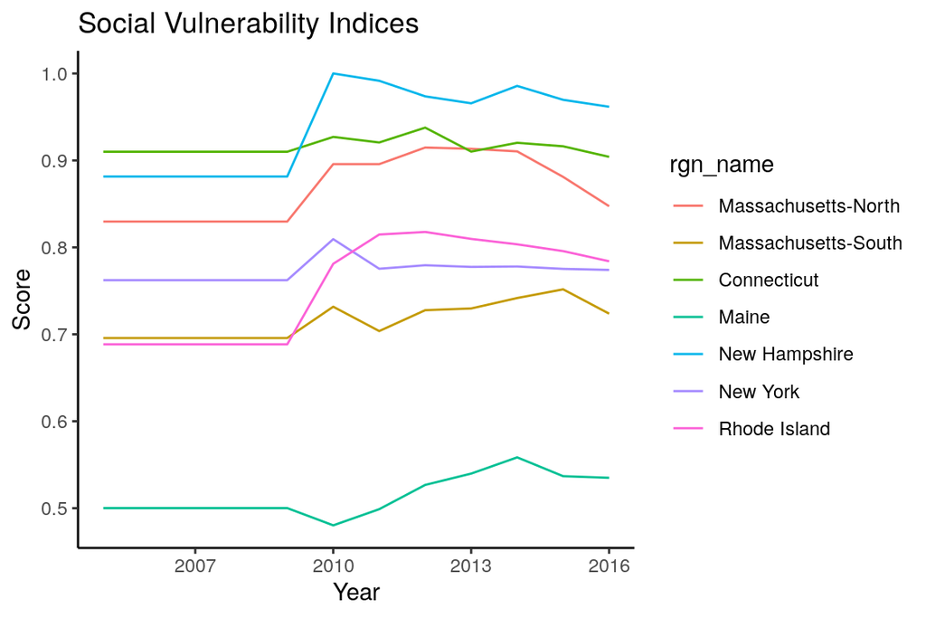

```r
svi_social_vul_graph <- ggplot(svi_social) +
  geom_line(aes(x=year, y= res_social_score, color = rgn_name)) +
  ggtitle("Social Vulnerability Indices") +
  ylab("Score") +
  xlab("Year") +
  theme_classic()

svi_gen_vul_graph <- ggplot(svi_gen) +
  geom_line(aes(x=year, y= res_gen_score, color = rgn_name)) +
  ggtitle("Gentrification Vulnerability Indices") +
  ylab("Score") +
  xlab("Year") +
  theme_classic()

svi_fish_vul_graph <- ggplot(svi_fish) +
  geom_line(aes(x=year, y= res_fish_score, color = rgn_name)) +
  ggtitle("Fishing Vulnerability Indices") +
  ylab("Score") +
  xlab("Year") +
  theme_classic()

svi_inun_vul_graph <- ggplot(svi_inund) +
  geom_line(aes(x=year, y= res_inund_score, color = rgn_name)) +
  ggtitle("Inundation Risk") +
  ylab("Score") +
  xlab("Year") +
  theme_classic()

svi_social_vul_graph
```

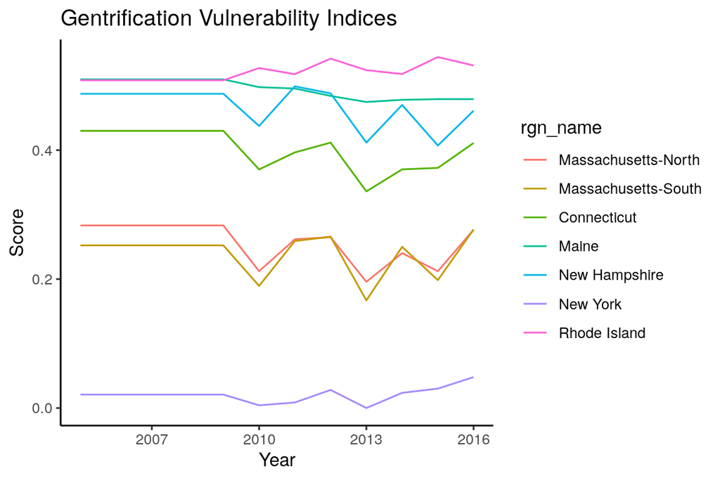

```r
ggsave("figs/svi_social_vul_graph.jpg", width=7, height=5, dpi=300)

svi_gen_vul_graph
```

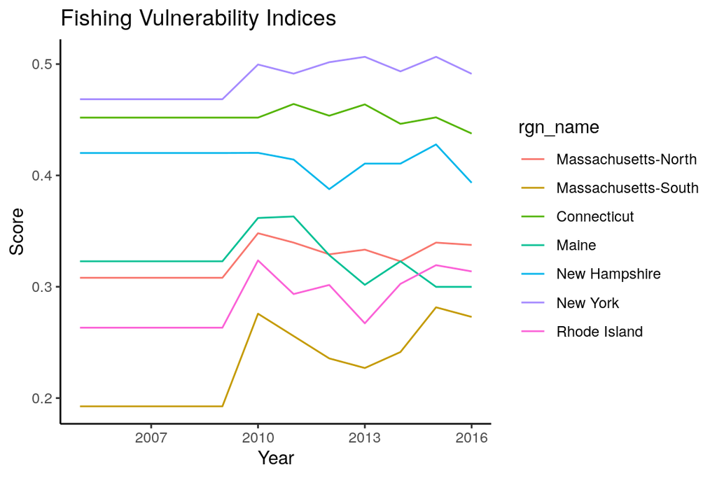

```r
ggsave("figs/svi_gen_vul_graph.jpg", width=7, height=5, dpi=300)

svi_fish_vul_graph
```

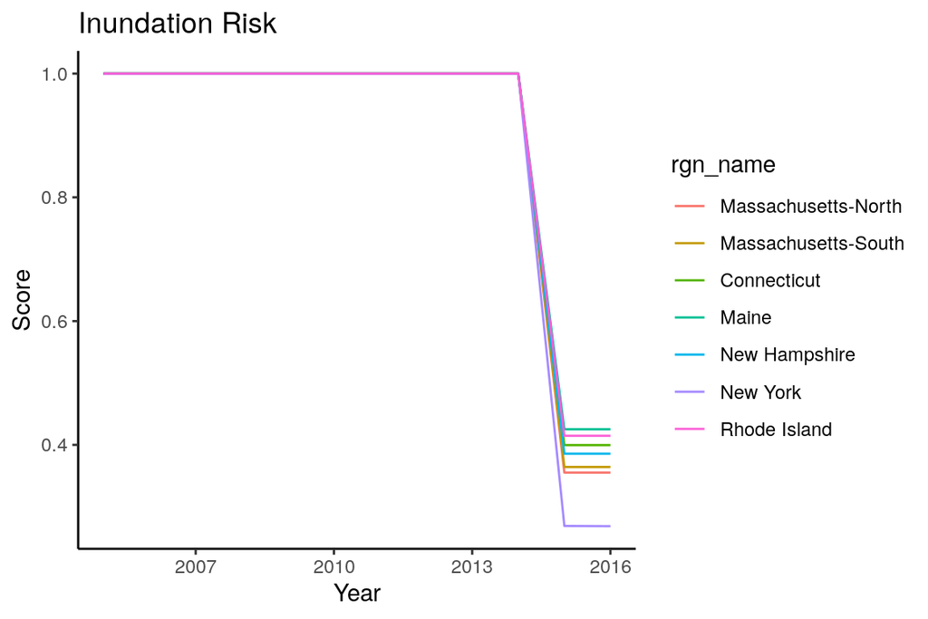

```r
ggsave("figs/svi_fish_vul_graph.jpg", width=7, height=5, dpi=300)

svi_inun_vul_graph
```

```r
ggsave("figs/svi_inun_vul_graph.jpg", width=7, height=5, dpi=300)
```

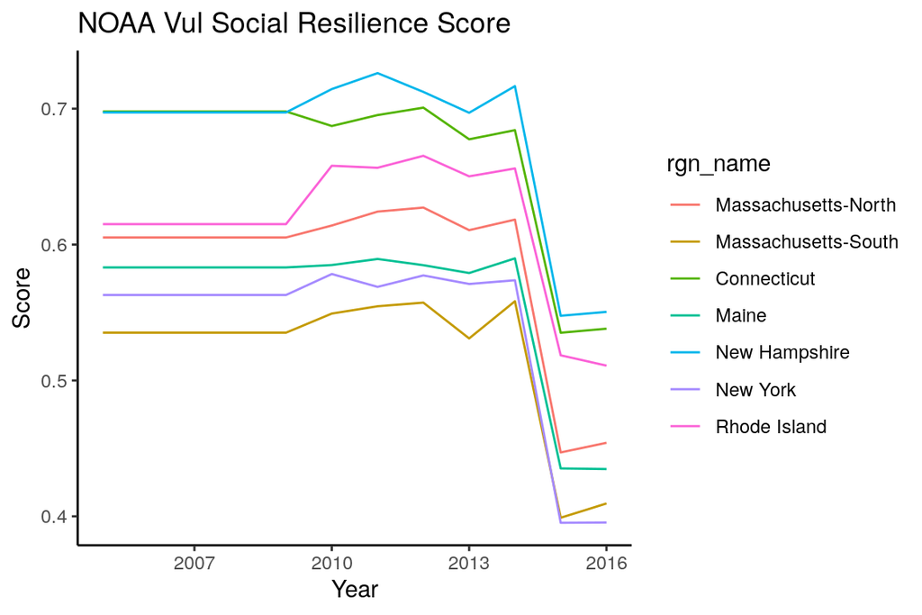

```r
noaa_vul_graph <- ggplot(noaa_vul) +
  geom_line(aes(x=year, y= noaa_vul_score, color = rgn_name)) +
  ggtitle("NOAA Vul Social Resilience Score") +
  ylab("Score") +
  xlab("Year") +
  theme_classic()

noaa_vul_graph
```

```r
ggsave("figs/noaa_vul_graph.jpg", width=7, height=5, dpi=300)
```